# Problem Set 3

```r
library(ggplot2)
library(NHANES)
df = NHANES
df = df[,c("BPSysAve","Age","Weight","Height","Gender")]
```

```r
head(df)
```

| BPSysAve | Age | Weight | Height | Gender |
| --- | --- | --- | --- | --- |
| 113 | 34 | 87.4 | 164.7 | male |
| 113 | 34 | 87.4 | 164.7 | male |
| 113 | 34 | 87.4 | 164.7 | male |
| NA | 4 | 17.0 | 105.4 | male |
| 112 | 49 | 86.7 | 168.4 | female |
| 86 | 9 | 29.8 | 133.1 | male |

Here we are dropping those rows which does not have the BPSysAve as replacing them with mean gives us spurious results

```r
colSums(is.na(df))
df = df[complete.cases(df, df$BPSysAve),]
```

**BPSysAve**

1449

**Age**

0

**Weight**

78

**Height**

353

**Gender**

0

```r
colSums(is.na(df))
```

**BPSysAve**

0

**Age**

0

**Weight**

0

**Height**

0

**Gender**

0

# # Section1: Relationship between Average Systolic Blood Pressure and Age

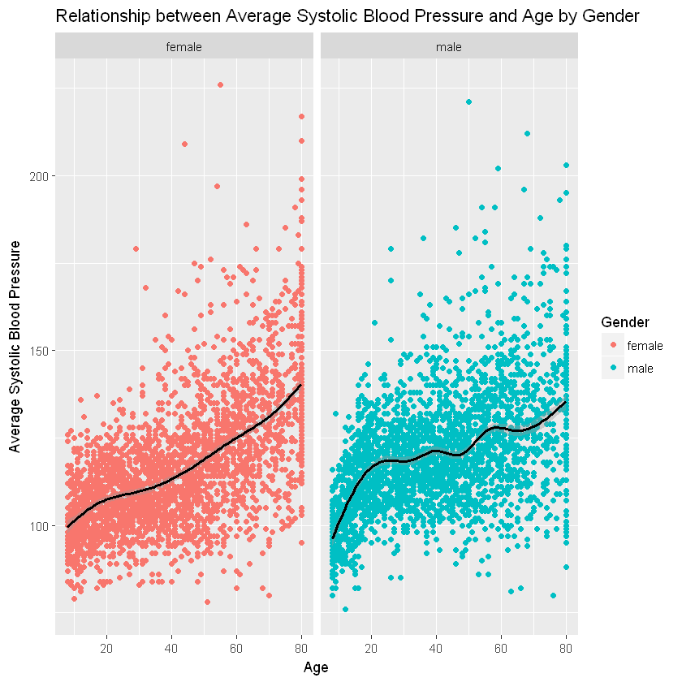

```r
ggplot(df,aes(x=Age,y=BPSysAve,color=Gender)) +  geom_point()  +
  geom_smooth( method.args= list(degree=1),col = "black",span=1) + facet_grid(~Gender) +
ylab("Average Systolic Blood Pressure") + ggtitle("Relationship between Average Systolic Blood Pressure and Age by Gender")
```

It looks like there is a weak Positive Correlation between Average Systolic Blood Pressure and Age.

The average systolic Blood Pressure increases gradually with age for both genders.

A definitive linear trend is not observed.

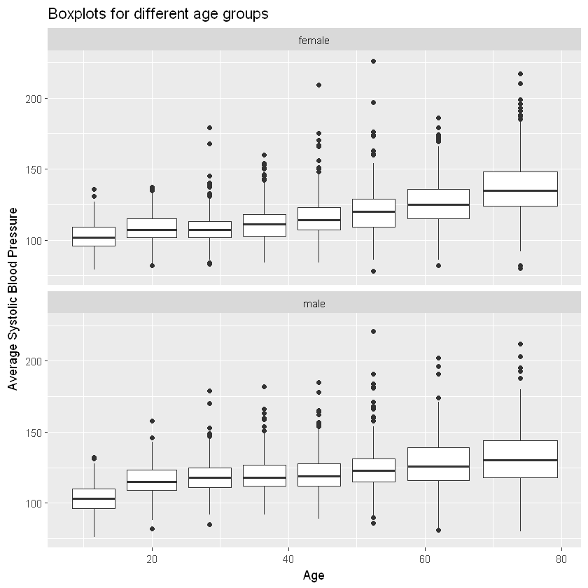

```r
ggplot(df, aes(x=Age,y=BPSysAve)) +geom_boxplot(aes(group= cut_number(Age, n = 8))) + facet_wrap(~Gender,ncol=1)+
ylab("Average Systolic Blood Pressure") + ggtitle("Boxplots for different age groups")
```

```r
library(broom)
df.lm= lm(BPSysAve ~ Age, data=df)
df.lm.au = augment(df.lm)
df.lm.au$Gender = df$Gender
```

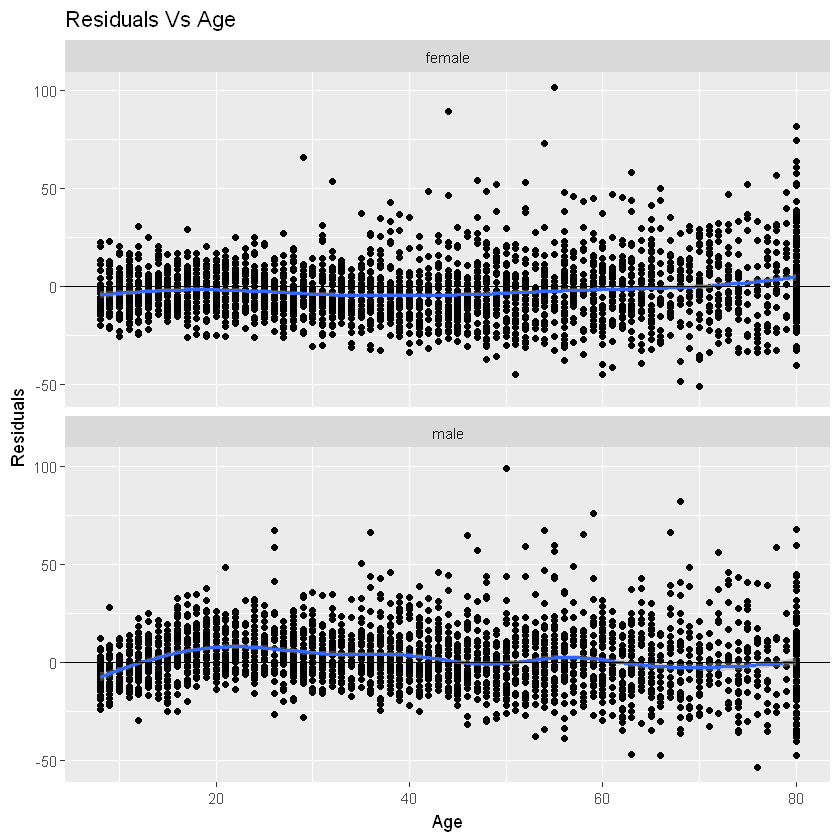

```r
ggplot(df.lm.au, aes(x=Age, y= .resid)) + geom_point() + geom_smooth() +
  geom_abline(slope = 0, intercept = 0)+ facet_wrap(~Gender,ncol=1) + ylab("Residuals") + ggtitle("Residuals Vs Age")
```

It looks like the model can be fitted best with a linear model. But the confidence level does not contain all the points, it means there is a less correlation between Average Systolic Blood Pressure and Age.

# Section2: Relationship between Average Systolic Blood Pressure and Weight

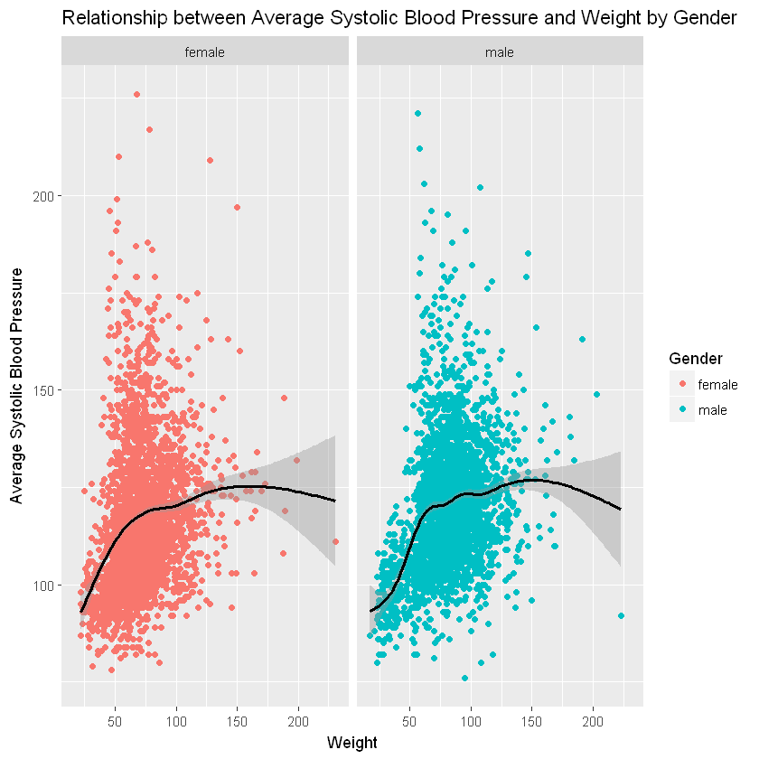

```r
ggplot(df,aes(x=Weight,y=BPSysAve,color=Gender)) +  geom_point()  +
  geom_smooth( method.args= list(degree=1),col = "black",span=1) + facet_grid(~Gender) +
ylab("Average Systolic Blood Pressure") + ggtitle("Relationship between Average Systolic Blood Pressure and Weight by Gender")
```

Eyeballing at the above plot, it can be said that Linear approximation model is not appropriate for this data for both the genders.

For weights about 150 and above, the Blood Pressure values deviate from the existing trend.

```r
library(broom)
df.lm.wt = lm(BPSysAve ~ Weight + I(Weight^2), data=df)
df.lm.wt.au = augment(df.lm.wt)
df.lm.wt.au$Gender = df$Gender
```

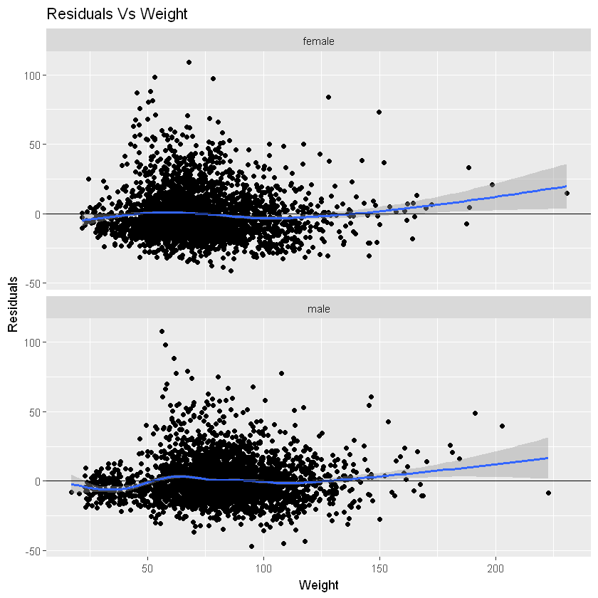

```r
ggplot(df.lm.wt.au, aes(x=Weight, y= .resid)) + geom_point() + geom_smooth() +
  geom_abline(slope = 0, intercept = 0)+ facet_wrap(~Gender,ncol=1) + ggtitle("Residuals Vs Weight") +
ylab("Residuals")
```

The curve moves just around zero. Thus the Quadratic model seems apt for this data.

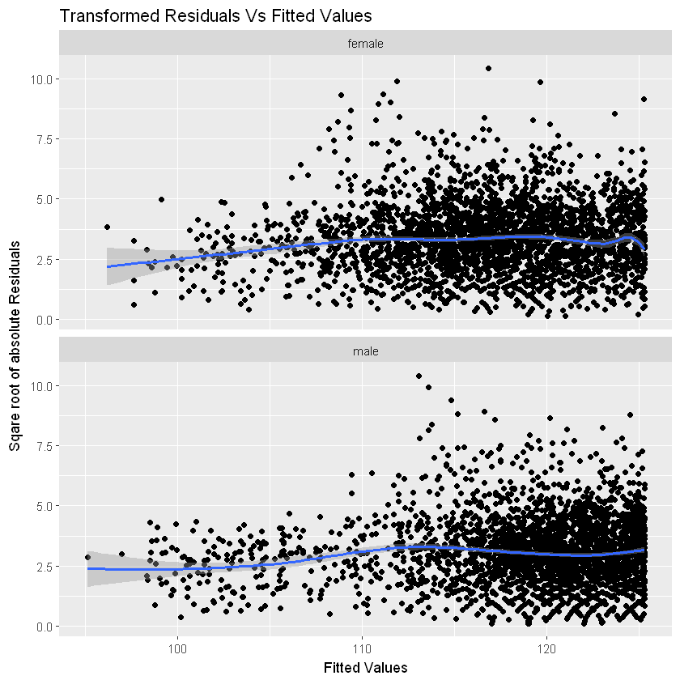

```r
ggplot(df.lm.wt.au, aes(x=.fitted, y= sqrt(abs(.resid)))) + geom_point() + geom_smooth() +
  facet_wrap(~Gender,ncol=1) + xlab("Fitted Values") + ylab("Sqare root of absolute Residuals") +
ggtitle("Transformed Residuals Vs Fitted Values")
```

The curve clearly appears to be a horizontal line which proves Homoscedasticity in the data. But the confidence band does not cover majority of data points.

# Section3: Relationship between Average Systolic Blood Pressure and Height

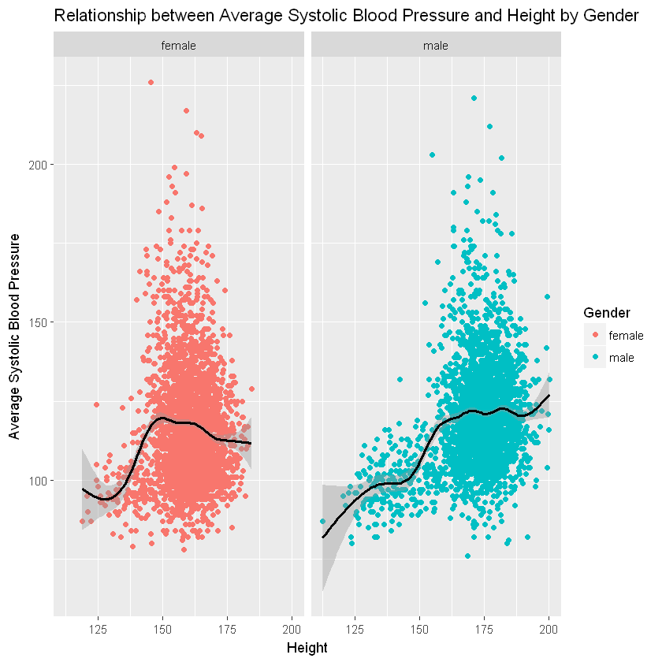

```r
ggplot(df,aes(x=Height,y=BPSysAve,color=Gender)) +  geom_point()  +
  geom_smooth(col = "black", span = 1) + facet_grid(~Gender) +
ylab("Average Systolic Blood Pressure") + ggtitle("Relationship between Average Systolic Blood Pressure and Height by Gender")
```

By looking at the above plot we can say that Linear model is not a best fit for the given data

```r
library(broom)
df.lm.ht = lm(BPSysAve ~ Height + I(Height^2), data=df)
df.lm.ht.au = augment(df.lm.ht)
df.lm.ht.au$Gender = df$Gender
```

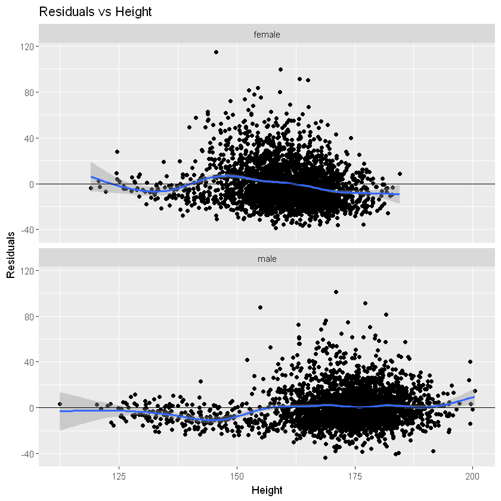

```r
ggplot(df.lm.ht.au, aes(x=Height, y= .resid)) + geom_point() + geom_smooth() +
  geom_abline(slope = 0, intercept = 0)+ facet_wrap(~Gender,ncol=1) + ylab("Residuals") +
ggtitle("Residuals vs Height")
```

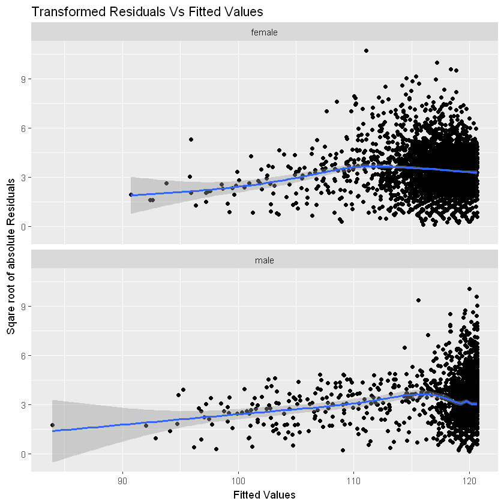

```r
ggplot(df.lm.ht.au, aes(x=.fitted, y= sqrt(abs(.resid)))) + geom_point() + geom_smooth() +
  facet_wrap(~Gender,ncol=1) + xlab("Fitted Values") + ylab("Sqare root of absolute Residuals") +
ggtitle("Transformed Residuals Vs Fitted Values")
```

It can clearly be observed that the confidence band does not include majority of the data points. The line is nearly horizontal for most portion of the curve.